# **Projet :** Analyse de la fidélité de 953 adhérents d’une mutuelle.

Luccin Pembele

## Introduction

Le Projet porte sur une analyse de la base de données “Duree_Mutelle.CSV” comportant 953 adhérents d’une mutuelle. L’objectif est de comprendre les facteurs determinants de la rupture de contrat. Les covariables qui vont être utilisé pour analyser leur infuence sont:

— AGE : en années. — PROP : est-ce que l’adhérent est propriétaire de son logement ? 1 Oui, 0 Non. — PROF : la catégorie socio-professionnelle qui contient huit modalités, codées de la façon suivante. 1 agriculteur, 2 artisan, 3 cadre, 4 profession intermédiaire, 5 employé, 6 ouvrier, 7 retraité, 8 autre. — HOMME : 1 si l’adhérent est un homme, 0 si c’est une femme.

La variable d’interêt est la durée qui s’écoule entre le début de la souscription et la fin de l’observations.

Nous allons effectuer pour ce projet des analyses non paramétrique (Kaplan-Meier, test du log-rank) pour comparer les courbes de survies et enfin nous allons effectuer le modèle de Cox pour quantifier l’impact des variables.

```r
rm(list=ls())

# Chargement des données
data=read.csv("Duree_Mutuelle.csv", sep=";")
head(data)
```

```
##   Obs AGE PROP PROF HOMME   DEBUT  FINOBS
## 1   1  49    0    5     1 2000,48 2010,66
## 2   2  57    0    6     1 2002,47  2015,8
## 3   3  37    0    5     1 2000,15 2010,23
## 4   4  44    0    2     1 2000,88  2015,8
## 5   5  60    1    7     1 2000,41 2010,31
## 6   6  58    1    8     1 2000,33 2006,17
```

```r
nrow(data)
```

```
## [1] 953
```

```r
data$DEBUT=as.numeric(gsub(",", ".", data$DEBUT))
data$FINOBS=as.numeric(gsub(",", ".", data$FINOBS))
data$PROP= as.factor(data$PROP)
data$PROF= as.factor(data$PROF)
data$HOMME= as.factor(data$HOMME)
```

```r
head(data)
```

```
##   Obs AGE PROP PROF HOMME   DEBUT  FINOBS
## 1   1  49    0    5     1 2000.48 2010.66
## 2   2  57    0    6     1 2002.47 2015.80
## 3   3  37    0    5     1 2000.15 2010.23
## 4   4  44    0    2     1 2000.88 2015.80
## 5   5  60    1    7     1 2000.41 2010.31
## 6   6  58    1    8     1 2000.33 2006.17
```

```r
# Construction des variables de survie
data$Tobs=data$FINOBS - data$DEBUT
data$status=ifelse(data$FINOBS < 2015.80, 1, 0)
```

## Analyses non-paramétriques des données (estimateur de Kaplan-Meier, tests du log-rang etc.)

```r
# 2. Analyses non-paramétriques
library(survival)
```

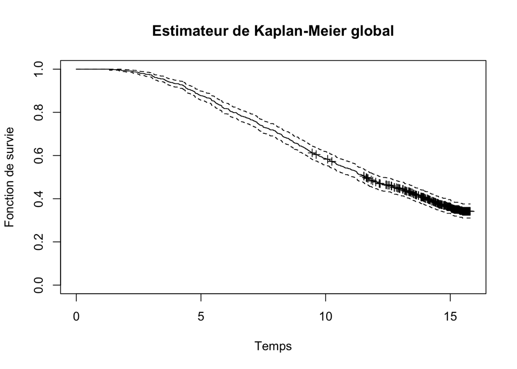

```r
# Estimateur de Kaplan-Meier global
KM_global=survfit(Surv(data$Tobs, data$status) ~ 1)
plot(KM_global, mark.time = TRUE, xlab = "Temps", ylab = "Fonction de survie", main = "Estimateur de Kaplan-Meier global")
```

```r
summary(survfit(Surv(data$Tobs, data$status)~ 1), mark.time=TRUE)
```

```
## Call: survfit(formula = Surv(data$Tobs, data$status) ~ 1)
##
##   time n.risk n.event survival std.err lower 95% CI upper 95% CI
##   1.33    953       2    0.998 0.00148        0.995        1.000
##   1.70    951       1    0.997 0.00181        0.993        1.000
##   1.72    950       1    0.996 0.00209        0.992        1.000
##   1.79    949       1    0.995 0.00234        0.990        0.999
##   1.82    948       1    0.994 0.00256        0.989        0.999
##   1.96    947       1    0.993 0.00277        0.987        0.998
##   2.01    946       1    0.992 0.00296        0.986        0.997
##   2.22    945       1    0.991 0.00313        0.984        0.997
##   2.26    944       1    0.990 0.00330        0.983        0.996
##   2.27    943       1    0.988 0.00346        0.982        0.995
##   2.29    942       1    0.987 0.00361        0.980        0.995
##   2.39    941       1    0.986 0.00376        0.979        0.994
##   2.46    940       1    0.985 0.00390        0.978        0.993
##   2.48    939       1    0.984 0.00403        0.976        0.992
##   2.51    938       1    0.983 0.00416        0.975        0.991
##   2.54    937       2    0.981 0.00441        0.973        0.990
##   2.59    935       1    0.980 0.00453        0.971        0.989
##   2.71    934       1    0.979 0.00464        0.970        0.988
##   2.75    933       1    0.978 0.00476        0.969        0.987
##   2.76    932       1    0.977 0.00486        0.967        0.986
##   2.79    931       1    0.976 0.00497        0.966        0.986
##   2.93    930       2    0.974 0.00518        0.964        0.984
##   3.01    928       1    0.973 0.00528        0.962        0.983
##   3.03    927       2    0.971 0.00547        0.960        0.981
##   3.04    925       1    0.970 0.00556        0.959        0.981
##   3.05    924       1    0.969 0.00566        0.957        0.980
##   3.06    923       1    0.967 0.00575        0.956        0.979
##   3.07    922       1    0.966 0.00584        0.955        0.978
##   3.11    921       2    0.964 0.00601        0.953        0.976
##   3.12    919       1    0.963 0.00609        0.951        0.975
##   3.14    918       1    0.962 0.00618        0.950        0.974
##   3.15    917       1    0.961 0.00626        0.949        0.974
##   3.23    916       1    0.960 0.00634        0.948        0.973
##   3.24    915       1    0.959 0.00642        0.947        0.972
##   3.27    914       1    0.958 0.00650        0.945        0.971
##   3.28    913       1    0.957 0.00657        0.944        0.970
##   3.36    912       1    0.956 0.00665        0.943        0.969
```

[output cut: 428 more lines]

```
##  14.63    255       1    0.372 0.01608        0.342        0.405
##  14.68    249       1    0.371 0.01608        0.340        0.404
##  14.71    245       1    0.369 0.01609        0.339        0.402
##  14.83    233       2    0.366 0.01610        0.336        0.399
##  14.86    229       1    0.364 0.01611        0.334        0.397
##  14.87    227       1    0.363 0.01612        0.332        0.396
##  15.01    207       1    0.361 0.01614        0.331        0.394
##  15.02    206       1    0.359 0.01616        0.329        0.392
##  15.03    204       2    0.356 0.01619        0.325        0.389
##  15.05    196       1    0.354 0.01621        0.324        0.387
##  15.11    183       1    0.352 0.01623        0.322        0.385
##  15.16    176       1    0.350 0.01626        0.319        0.383
##  15.35    139       1    0.347 0.01634        0.317        0.381
##  15.38    129       1    0.345 0.01643        0.314        0.379
##  15.48    109       1    0.342 0.01658        0.311        0.376
```

```r
quantile(KM_global)
```

```
## $quantile
##    25    50    75
##  7.26 11.57    NA
##
## $lower
##    25    50    75
##  6.80 11.13    NA
##
## $upper
##    25    50    75
##  7.76 12.28    NA
```

En analysant l’estimateur de Kaplan-Meier de chaque covariable, on observe:

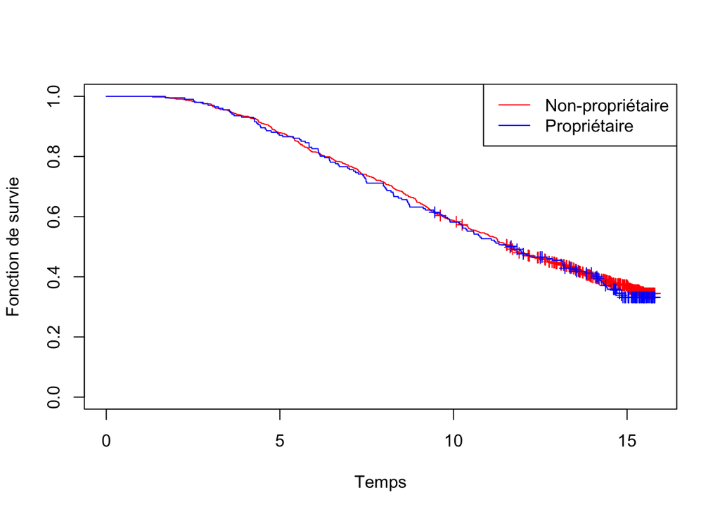

```r
# KM par propriétaire
KM_PROP=survfit(Surv(data$Tobs, data$status) ~ data$PROP)
plot(KM_PROP, mark.time = TRUE, col = c("red", "blue"), xlab = "Temps", ylab = "Fonction de survie")
legend("topright", c("Non-propriétaire", "Propriétaire"),
       col = c("red", "blue"), lty = 1)
```

```r
# Test du log-rank
survdiff(Surv(data$Tobs, data$status) ~ data$PROP)
```

```
## Call:
## survdiff(formula = Surv(data$Tobs, data$status) ~ data$PROP)
##
##               N Observed Expected (O-E)^2/E (O-E)^2/V
## data$PROP=0 752      472      476    0.0275     0.131
## data$PROP=1 201      130      126    0.1035     0.131
##
##  Chisq= 0.1  on 1 degrees of freedom, p= 0.7
```

```r
quantile(KM_PROP)
```

```
## $quantile
##               25    50 75
## data$PROP=0 7.29 11.57 NA
## data$PROP=1 7.18 11.74 NA
##
## $lower
##               25    50 75
## data$PROP=0 6.80 11.04 NA
## data$PROP=1 6.16 10.27 NA
##
## $upper
##               25    50 75
## data$PROP=0 7.92 12.46 NA
## data$PROP=1 8.20 13.47 NA
```

Concernant, l’estimateur de Kaplan-Meier pour les propriétaires et non propriétaire, on observe graphiquement que la courbe de survie des propriétaires est quasiment la même avec celle des non propriétaires. Cela signifie que la probabilité de rester adhérents semble être quasiment la même chez les propriétaires et les non propriétaires. En analysant le test du Log-Rank,cela confirme que les fonctions de survie sont en effet égales car la p-valeur est très elevée avec p= 0.7, on doit, par conséquent, ne pas rejetter l’hypothèse nulle.

Pour rappel,
$$(H_0):
S_\text{propriétaire}= S_\text{NonPropriétaire}$$
contre
$$(H_1): S_\text{propriétaire}\neq
S_\text{NonPropriétaire}$$

En analysant les quantiles:

- 25% des propriétaires adherents ont rompu leur contrat avant 7.18 ans.
- 25% des non propriétaires adherents ont rompu leur contrat avant 7.29 ans.
- 50% des propriétaires adherents ont rompu leur contrat avant 11.74 ans.
- 50% des non propriétaires adherents ont rompu leur contrat avant 11.57 ans.

  On retrouve des quantiles quasiment similaires pour les deux groupes. Le fait d’être propriétaire ou non n’influe pas sur la fidélité de l’adhérent.

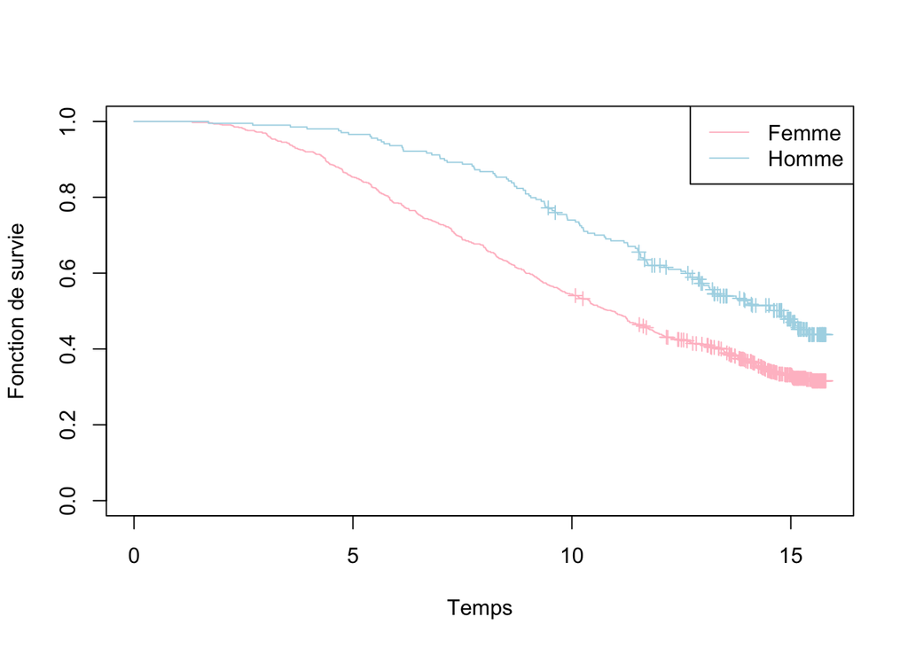

```r
# KM par sexe
KM_sexe=survfit(Surv(data$Tobs, data$status) ~ data$HOMME)
plot(KM_sexe, mark.time = TRUE, col = c("pink", "lightblue"), xlab = "Temps", ylab = "Fonction de survie")
legend("topright", c("Femme", "Homme"), col = c("pink", "lightblue"), lty = 1)
```

```r
# Test du log-rank pour le sexe
survdiff(Surv(data$Tobs, data$status) ~ data$HOMME)
```

```
## Call:
## survdiff(formula = Surv(data$Tobs, data$status) ~ data$HOMME)
##
##                N Observed Expected (O-E)^2/E (O-E)^2/V
## data$HOMME=0 749      497      449       5.2      20.5
## data$HOMME=1 204      105      153      15.2      20.5
##
##  Chisq= 20.5  on 1 degrees of freedom, p= 6e-06
```

```r
quantile(KM_sexe)
```

```
## $quantile
##                25    50 75
## data$HOMME=0 6.57 10.92 NA
## data$HOMME=1 9.88 14.83 NA
##
## $lower
##                25    50 75
## data$HOMME=0 6.12 10.17 NA
## data$HOMME=1 9.06 13.13 NA
##
## $upper
##                 25    50 75
## data$HOMME=0  7.24 11.55 NA
## data$HOMME=1 11.19    NA NA
```

En regardant pour le sexe. On observe graphiquement, la courbe de survie des hommes et supérieur à celle des femmes donc la probabilité de rester adhérents chez les hommes est supérieur à celles des femmes.

Le test du Log-Rank confirme cette analyse. Les courbes de survie sont en effet significativemnt differentes car la p-valeur est très faible avec p=6e-06, on rejette l’hypothèse nulle.  
En analysant les quantiles:

- 25% des hommes adherents ont rompu leur contrat avant 9.88 ans.
- 25% des femmes adherentes ont rompu leur contrat avant 6.57 ans.
- 50% des hommes adherents ont rompu leur contrat avant 14.84 ans.
- 50% des femmes adherentes ont rompu leur contrat avant 10.92 ans.

  Les hommes maintiennent leurs contrats plus longtemps que les femmes avec un écart de 3 ans de plus chez les hommes au 1er quartile et 4 ans de plus chez les hommes à la médiane.

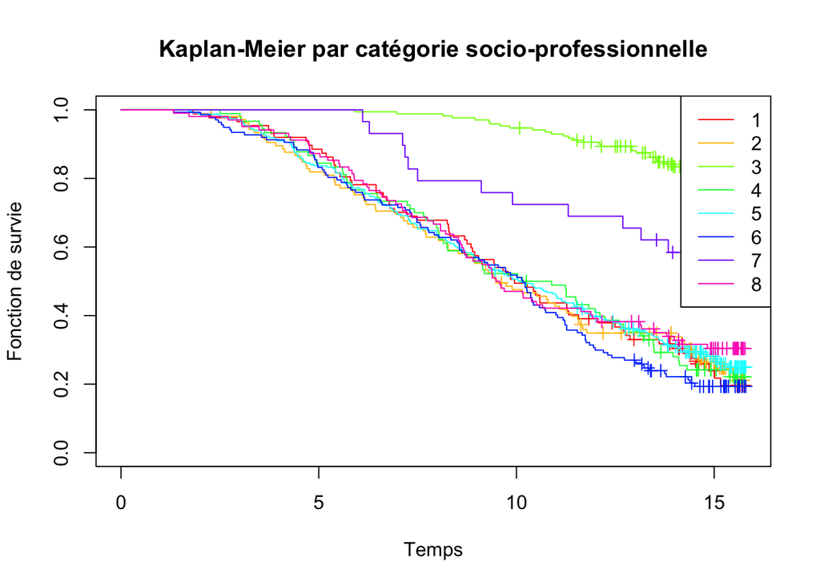

```r
# KM par catégorie socio-professionnelle
KM_PROF=survfit(Surv(data$Tobs, data$status) ~ data$PROF)
couleur= rainbow(8)
plot(KM_PROF, mark.time = TRUE, xlab = "Temps",
     ylab = "Fonction de survie", main = "Kaplan-Meier par catégorie socio-professionnelle", col=couleur)
legend("topright", legend=levels(data$PROF), col = couleur, lty = 1)
```

```r
survdiff(Surv(data$Tobs, data$status) ~ data$PROF)
```

```
## Call:
## survdiff(formula = Surv(data$Tobs, data$status) ~ data$PROF)
##
##               N Observed Expected (O-E)^2/E (O-E)^2/V
## data$PROF=1  87       66     49.3      5.68      6.19
## data$PROF=2 105       77     57.1      6.94      7.68
## data$PROF=3 170       31    158.9    102.95    142.55
## data$PROF=4  90       68     51.1      5.59      6.12
## data$PROF=5 233      168    131.2     10.30     13.21
## data$PROF=6 137      109     72.5     18.35     20.97
## data$PROF=7  29       13     23.2      4.45      4.64
## data$PROF=8 102       70     58.7      2.16      2.40
##
##  Chisq= 160  on 7 degrees of freedom, p= <2e-16
```

```r
quantile(KM_PROF)
```

```
## $quantile
##               25    50    75
## data$PROF=1 6.63  9.95 14.87
## data$PROF=2 6.12  9.50 15.02
## data$PROF=3   NA    NA    NA
## data$PROF=4 6.48 10.52 14.31
## data$PROF=5 6.29 10.08 15.35
## data$PROF=6 6.14 10.16 13.23
## data$PROF=7 9.90    NA    NA
## data$PROF=8 6.60  9.53    NA
##
## $lower
##                25    50    75
## data$PROF=1  5.42  8.89 12.87
## data$PROF=2  4.77  8.53 14.18
## data$PROF=3 14.86    NA    NA
## data$PROF=4  5.60  8.26 13.23
## data$PROF=5  5.60  9.10 14.10
## data$PROF=6  5.18  8.70 11.85
## data$PROF=7  7.18 13.15    NA
## data$PROF=8  5.84  8.69 13.99
##
## $upper
##               25    50 75
## data$PROF=1 8.31 12.06 NA
## data$PROF=2 7.64 11.55 NA
## data$PROF=3   NA    NA NA
## data$PROF=4 8.04 12.60 NA
## data$PROF=5 7.26 11.46 NA
## data$PROF=6 7.56 10.74 NA
## data$PROF=7   NA    NA NA
## data$PROF=8 8.08 11.92 NA
```

En examinant les catégories socio-professionnelles, on observe graphiquement, tous les courbes de survie se superposent sauf 2 courbes de survie qui se distinguent. On parle des courbes de survie des cadres (3) et des retraités (7).

Le test du Log-Rank valide cette analyse, il existe au moins une courbe de survie significativement différente des autres car la p-valeur est très faible avec p=<2e-16.

En analysant les quantiles:

Globalement, 25% des adhérents ont rompu leur contrat avant 6-7 ans hormis les retraités, qui pour eux, 25% des adhérents ont rompu leur contrat avant 9.90 ans et les cadres, dont leur seuil à 25% n’est pas atteit à la fin de la période d’observation.

## Implémentation d’un modèle de Cox

```r
# 3. Modèle de Cox
coxph(Surv(data$Tobs, data$status) ~data$AGE +data$PROP + data$PROF + data$HOMME)
```

```
## Call:
## coxph(formula = Surv(data$Tobs, data$status) ~ data$AGE + data$PROP +
##     data$PROF + data$HOMME)
##
##                  coef exp(coef)  se(coef)      z        p
## data$AGE    -0.028890  0.971523  0.005696 -5.072 3.94e-07
## data$PROP1   0.250792  1.285043  0.105965  2.367   0.0179
## data$PROF2  -0.009564  0.990482  0.168139 -0.057   0.9546
## data$PROF3  -1.961335  0.140671  0.218303 -8.984  < 2e-16
## data$PROF4   0.002457  1.002460  0.173320  0.014   0.9887
## data$PROF5  -0.037783  0.962921  0.145353 -0.260   0.7949
## data$PROF6   0.162619  1.176588  0.156865  1.037   0.2999
## data$PROF7  -0.416642  0.659257  0.323751 -1.287   0.1981
## data$PROF8  -0.070622  0.931814  0.172169 -0.410   0.6817
## data$HOMME1 -0.480104  0.618719  0.108003 -4.445 8.78e-06
##
## Likelihood ratio test=253.4  on 10 df, p=< 2.2e-16
## n= 953, number of events= 602
```

```r
(1-0.971523)*100
```

```
## [1] 2.8477
```

```r
(1-0.618719)*100
```

```
## [1] 38.1281
```

```r
(1-0.140671)*100
```

```
## [1] 85.9329
```

```r
(1.285043-1)*100
```

```
## [1] 28.5043
```

Dans le modèle de Cox, on observe que le modèle est globalement très significatif. Les variables Âge, Sexe, la profession Cadres (3) sont très significatives avec des p-valeur très faible.Ce qui nous confirme nos analyses non paramétrique. La variable propriétaire est aussi significatif à 5% avec une p-valeur de 0.0179, étonnant sachant que l’on a demontré, d’après le test du Log-Rank, le fait d’être propriétaire ou non n’influence pas la fidélité de l’adhérent.  
En analysant le modèle:

- Un augmentation d’une année de l’adhèrent diminue le risque de rupture de contrat de 2.8477%
- Le risque de rupture de contrat est diminué de 38, 12181% chez les hommes par rapport aux femmes.
- Le risque de rupture de contrat est diminué de 85.9329% chez les cadres par rapport aux agriculteurs .
- Le risque de rupture de contrat est augmenté de 28.5043% chez les propriétaires par rapport aux non propriétaires.

```r
# Vérification des hypothèses (résidus de Schoenfeld)
model_cox = coxph(Surv(Tobs, status) ~ AGE + PROP + PROF + HOMME, data = data)
summary(model_cox)
```

[output not shown]

```
## Call:
## coxph(formula = Surv(Tobs, status) ~ AGE + PROP + PROF + HOMME,
##     data = data)
##
##   n= 953, number of events= 602
##
##             coef exp(coef)  se(coef)      z Pr(>|z|)
## AGE    -0.028890  0.971523  0.005696 -5.072 3.94e-07 ***
## PROP1   0.250792  1.285043  0.105965  2.367   0.0179 *
## PROF2  -0.009564  0.990482  0.168139 -0.057   0.9546
## PROF3  -1.961335  0.140671  0.218303 -8.984  < 2e-16 ***
## PROF4   0.002457  1.002460  0.173320  0.014   0.9887
## PROF5  -0.037783  0.962921  0.145353 -0.260   0.7949
## PROF6   0.162619  1.176588  0.156865  1.037   0.2999
## PROF7  -0.416642  0.659257  0.323751 -1.287   0.1981
## PROF8  -0.070622  0.931814  0.172169 -0.410   0.6817
## HOMME1 -0.480104  0.618719  0.108003 -4.445 8.78e-06 ***
## ---
## Signif. codes:  0 '***' 0.001 '**' 0.01 '*' 0.05 '.' 0.1 ' ' 1
##
##        exp(coef) exp(-coef) lower .95 upper .95
## AGE       0.9715     1.0293    0.9607    0.9824
## PROP1     1.2850     0.7782    1.0440    1.5817
## PROF2     0.9905     1.0096    0.7124    1.3771
## PROF3     0.1407     7.1088    0.0917    0.2158
## PROF4     1.0025     0.9975    0.7137    1.4080
## PROF5     0.9629     1.0385    0.7242    1.2803
## PROF6     1.1766     0.8499    0.8652    1.6001
## PROF7     0.6593     1.5169    0.3495    1.2435
## PROF8     0.9318     1.0732    0.6649    1.3058
## HOMME1    0.6187     1.6162    0.5007    0.7646
##
## Concordance= 0.681  (se = 0.011 )
## Likelihood ratio test= 253.4  on 10 df,   p=<2e-16
## Wald test            = 164.7  on 10 df,   p=<2e-16
## Score (logrank) test = 202.6  on 10 df,   p=<2e-16
```

```r
print(model_cox)
```

```
## Call:
## coxph(formula = Surv(Tobs, status) ~ AGE + PROP + PROF + HOMME,
##     data = data)
##
##             coef exp(coef)  se(coef)      z        p
## AGE    -0.028890  0.971523  0.005696 -5.072 3.94e-07
## PROP1   0.250792  1.285043  0.105965  2.367   0.0179
## PROF2  -0.009564  0.990482  0.168139 -0.057   0.9546
## PROF3  -1.961335  0.140671  0.218303 -8.984  < 2e-16
## PROF4   0.002457  1.002460  0.173320  0.014   0.9887
## PROF5  -0.037783  0.962921  0.145353 -0.260   0.7949
## PROF6   0.162619  1.176588  0.156865  1.037   0.2999
## PROF7  -0.416642  0.659257  0.323751 -1.287   0.1981
## PROF8  -0.070622  0.931814  0.172169 -0.410   0.6817
## HOMME1 -0.480104  0.618719  0.108003 -4.445 8.78e-06
##
## Likelihood ratio test=253.4  on 10 df, p=< 2.2e-16
## n= 953, number of events= 602
```

```r
(1-0.971523)*100
```

```
## [1] 2.8477
```

```r
(1-0.618719)*100
```

```
## [1] 38.1281
```

```r
(1-0.140671)*100
```

```
## [1] 85.9329
```

```r
(1.285043-1)*100
```

```
## [1] 28.5043
```

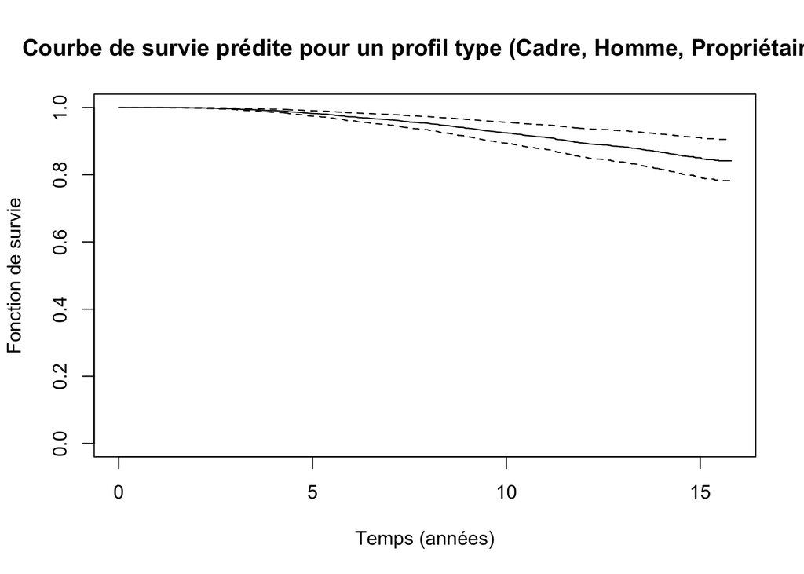

```r
# Courbe de survie prédite pour un profil type
new_data <- data.frame(
  AGE = mean(data$AGE),
  PROP = factor(1, levels = levels(data$PROP)),
  PROF = factor(3, levels = levels(data$PROF)),
  HOMME = factor(1, levels = levels(data$HOMME))
)


surv_fit = survfit(model_cox, newdata = new_data)
plot(surv_fit, xlab = "Temps (années)", ylab = "Fonction de survie",
     main = "Courbe de survie prédite pour un profil type (Cadre, Homme, Propriétaire)")
```

## Conclusion

D’après les analyses non paramétriques et le modèle de Cox, nous constatons que les hommes maintiennent leur contrat plus longtemps que les femmes, avec un écart de près de 4 ans sur les **médianes de survie** (14,84 ans pour les hommes contre 10,92 ans pour les femmes). Nous avons pu constater que les cadres ainsi que les retraités se distinguent par rapport aux autres catégories socioprofessionnelles. Cela nous a été confirmé sur les courbes de survie et le test du log-rank. Les cadres sont des clients qui résilient rarement tandis que les retraités sont des clients qui maintiennent leur contrat plus longtemps que les autres catégories (25% résilient avant 9,90 ans pour les retraités contre 6-7 ans pour les autres catégories).

- Plus l’adhérent est âgé, moins il risque de résilier (baisse du risque de 2,85% par an d’âge).
- Les hommes risquent moins de résilier que les femmes (risque diminué de 38,12%).
- Les cadres risquent moins de résilier que les autres catégories comme les agriculteurs (risque diminué de 85,93%).
- La vraie surprise provient de la variable “propriétaire”. Alors que le test du log-rank indiquait que le fait d’être propriétaire ou non n’influençait pas la survie globale, elle devient significative dans le modèle de Cox, augmentant le risque de résiliation de 28,50%.

Donc le profil d’un adhérent qui ne compte pas résilier est un homme âgé ayant un statut de cadre et qui est locataire (non-propriétaire). Le profil d’un adhérent qui compte résilier très rapidement est une femme jeune qui n’est pas cadre et qui est propriétaire.